# R Lab: Generalized Linear Models

STA 631 – Statistical Modeling I

Author

Andrew DiLernia

Once completed, submit a zipped file (.zip) containing two total documents via Blackboard: a .qmd Quarto file and the corresponding HTML document.

In this assignment we will be analyzing data on annual Atlantic hurricane counts, summer North Atlantic sea surface temperatures, and El Niño–Southern Oscillation (ENSO) climate phases from 1950 to 2022, compiled from the National Oceanic and Atmospheric Administration (NOAA).

For this data, we will be concerned with the variables `year`, `hurricane_count`, `sea_surface_temperature_f`, and `enso_state`. A data dictionary for this data set is included below.

Table 1: Data dictionary for the Atlantic hurricanes data set.

| Variable | Description |
| --- | --- |
| year | Year of the Atlantic hurricane season (1950 to 2022) |
| hurricane_count | Annual number of Atlantic storms reaching at least Category 1 hurricane intensity (maximum sustained winds of at least 64 knots / 74 mph) |
| sea_surface_temperature_f | Average North Atlantic sea surface temperature from June through August in degrees Fahrenheit (°F) |
| enso_state | El Niño–Southern Oscillation (ENSO) climate phase from August through October based on the Oceanic Niño Index (Neutral, El Niño, or La Niña) |

## 1

1. First, import data on Atlantic hurricanes between 1950 and 2022 for this lab from https://raw.githubusercontent.com/dilernia/STA631/main/data/hurricanes_data_1950-2022.csv. Modify the `enso_state` variable to be a factor type with `"Neutral"` as the first or baseline category, `"El Niño"` as the second category, and `"La Niña"` as the third category.
2. Reproduce the histogram of `hurricane_count` (using `binwidth = 1`) as provided below.

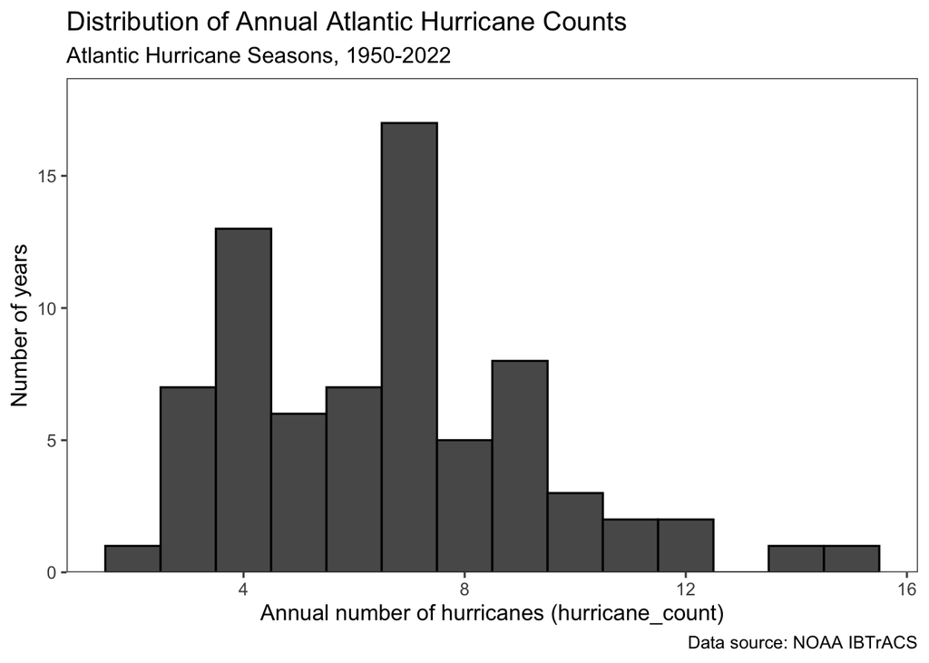

3. Reproduce the scatter plot of `hurricane_count` by `sea_surface_temperature_f` with a fitted Poisson loglinear regression curve (`method = "glm"`, `method.args = list(family = "poisson")`, `se = FALSE`) as provided below.

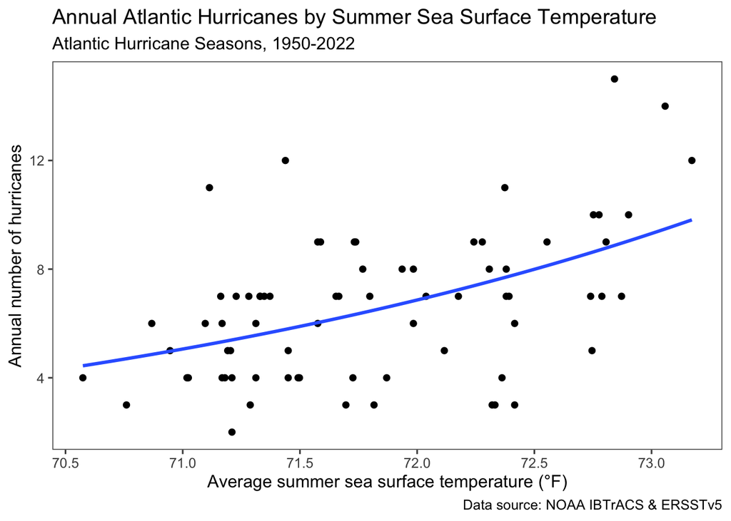

4. Reproduce the side-by-side box plots of `hurricane_count` by `enso_state` (using `scale_fill_viridis_d()`) as provided below.

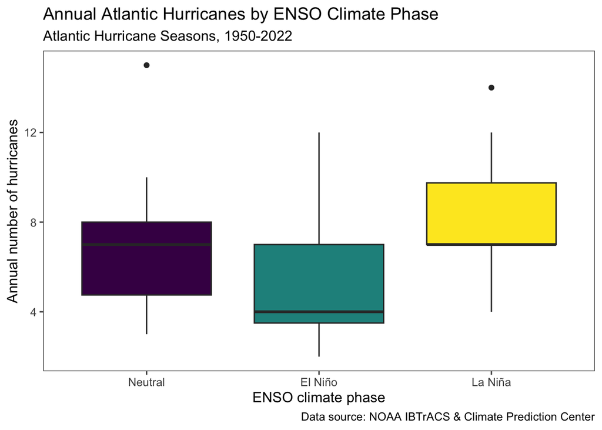

5. Reproduce the summary table of descriptive statistics for `hurricane_count` stratified by `enso_state` exactly as provided below.

Table 2: Summary statistics for annual Atlantic hurricane counts stratified by ENSO climate phase.

| enso_state | N | Minimum | Q1 | Median | Q3 | Maximum | Mean | Variance | SD |
| --- | --- | --- | --- | --- | --- | --- | --- | --- | --- |
| Neutral | 36 | 3 | 4.75 | 7 | 8 | 15 | 6.53 | 6.31 | 2.51 |
| El Niño | 19 | 2 | 3.5 | 4 | 7 | 12 | 5.26 | 6.76 | 2.6 |
| La Niña | 18 | 4 | 7 | 7 | 9.75 | 14 | 8.22 | 6.42 | 2.53 |

## 2

1. Fit a Poisson loglinear regression model with summer North Atlantic sea surface temperature in degrees Fahrenheit (`sea_surface_temperature_f`) and the ENSO climate phase (`enso_state`) as the predictor variables and the annual number of Atlantic hurricanes (`hurricane_count`) as the response variable.
2. Reproduce the model output on the log-count scale (`exponentiate = FALSE`) exactly as displayed below.

| **Characteristic** | **log(IRR)** | **95% CI** | **p-value** | **GVIF** | **Adjusted GVIF**<sup>1</sup> |
| --- | --- | --- | --- | --- | --- |
| (Intercept) | -17 | -27, -7.4 | <0.001 |  |  |
| sea_surface_temperature_f | 0.27 | 0.13, 0.41 | <0.001 | 1.0 | 1.0 |
| enso_state |  |  |  | 1.0 | 1.0 |
| Neutral | — | — |  |  |  |
| El Niño | -0.20 | -0.44, 0.03 | 0.10 |  |  |
| La Niña | 0.17 | -0.04, 0.38 | 0.11 |  |  |

<sup>1</sup> GVIF[^1]  
Abbreviations: CI = Confidence Interval, GVIF = Generalized Variance Inflation Factor, IRR = Incidence Rate Ratio  
Null deviance = 78.8; Null df = 72; Log-likelihood = -160; AIC = 328; BIC = 337; Deviance = 52.3; Residual df = 69; No. Obs. = 73

3. Reproduce the exponentiated model output (incidence rate ratios, `exponentiate = TRUE`) exactly as displayed below.

| **Characteristic** | **IRR** | **95% CI** | **p-value** | **GVIF** | **Adjusted GVIF**<sup>1</sup> |
| --- | --- | --- | --- | --- | --- |
| (Intercept) | 0.00 | 0.00, 0.00 | <0.001 |  |  |
| sea_surface_temperature_f | 1.31 | 1.14, 1.50 | <0.001 | 1.0 | 1.0 |
| enso_state |  |  |  | 1.0 | 1.0 |
| Neutral | — | — |  |  |  |
| El Niño | 0.82 | 0.65, 1.03 | 0.10 |  |  |
| La Niña | 1.18 | 0.96, 1.46 | 0.11 |  |  |

<sup>1</sup> GVIF[^2]  
Abbreviations: CI = Confidence Interval, GVIF = Generalized Variance Inflation Factor, IRR = Incidence Rate Ratio  
Null deviance = 78.8; Null df = 72; Log-likelihood = -160; AIC = 328; BIC = 337; Deviance = 52.3; Residual df = 69; No. Obs. = 73

## 3

1. Give a formal statement of the *assumed* Poisson loglinear regression model, clearly defining the response variable and all predictor variables in context.
2. Give a statement of the *estimated* Poisson loglinear regression model, clearly defining the response variable and all predictor variables in context.

## 4

1. Obtain diagnostic plots for the fitted Poisson regression model using methods covered in class.
2. Assess the assumptions for the Poisson regression model, clearly stating whether or not each assumption is met and citing specific evidence from the obtained output.

## 5

1. Provide the value of and interpret the estimated slope for `sea_surface_temperature_f` in context.
2. Provide the value of and interpret the estimated coefficient for the indicator variable for `El Niño` in context.
3. Provide the value of and interpret the estimated intercept in context. Is it sensible and appropriate to interpret the intercept here, or is it considered extrapolation? Why or why not?

## 6

1. Calculate the predicted number of Atlantic hurricanes ($\hat{\mu}$) for a season where the average summer North Atlantic sea surface temperature is $72.5^\circ\text{F}$ and the climate phase is **Neutral**. Is this considered extrapolation?
2. Calculate the predicted number of Atlantic hurricanes ($\hat{\mu}$) in a year with an average summer North Atlantic sea surface temperature of $72.5^\circ\text{F}$ during an *El Niño* climate phase. Is this considered extrapolation?

## 7

1. Finally, we will compare four candidate regression models for `hurricane_count`:
1. **Model 1 (`poisson_sst`)**: Poisson GLM (log link) with `sea_surface_temperature_f` only
2. **Model 2 (`poisson_enso`)**: Poisson GLM (log link) with `enso_state` only
3. **Model 3 (`hurr_model`)**: Poisson GLM (log link) with `sea_surface_temperature_f` and `enso_state`
4. **Model 4 (`nb_model`)**: Negative binomial GLM (log link) with `sea_surface_temperature_f` and `enso_state`

Fit the remaining candidate models and reproduce the summary table of `BIC` values across all four models (rounded to 2 decimal places) exactly as displayed below.

Table 3: Summary of BIC values across candidate regression models for annual Atlantic hurricane counts.

| Model | BIC |
| --- | --- |
| 1. Poisson (log link): sea_surface_temperature_f | 336.76 |
| 2. Poisson (log link): enso_state | 347.51 |
| 3. Poisson (log link): sea_surface_temperature_f + enso_state | 337.47 |
| 4. Negative binomial (log link): sea_surface_temperature_f + enso_state | 341.76 |

2. Comparing the three Poisson GLMs (Models 1, 2, and 3), which model is preferred based on BIC?
3. Based on the BIC values, which model is overall (including the negative binomial model) most preferred for modeling annual hurricane counts?

## Footnotes

[^1]: 1/(2*df)
[^2]: 1/(2*df)